# Monday NIMBLE

Mike Li, Morgan Kain

11:00 30 November 2015

```r
library(knitr)
options(mc.cores = parallel::detectCores())
#opts_chunk$set(cache = TRUE)
```

## NIMBLE: Numerical Inference for statistical Models for Bayesian and Likelihood Estimation

NIMBLE is built in R but compiles your models and algorithms using C++ for speed  
NIMBLE is most commonly used for MCMC but can also be used to implement a series of other algorithms (e.g. particle filtering, MCEM)  
1. A system for writing statistical models flexibly, which is an extension of the BUGS language  
2. A library of algorithms such as MCMC.  
3. A language, called NIMBLE, embedded within and similar in style to R, for writing algorithms that operate on BUGS models.

One of the most important concepts behind NIMBLE is to allow a combination of highlevel processing in R and low-level processing in compiled C++.

##### Why NIMBLE?

1. Options (More customizable MCMC, ability to run JAGS models and STAN models, EM, particle filter) that leads to a more adaptable workflow
2. User-defined functions and distributions – written as nimbleFunctions – can be used in model code.
3. Multiple parameterizations for distributions, similar to those in R, can be used.  
   e.g. normal distribution with BUGS parameter order:  
   x ~ dnorm(a + b * c, tau)  
   normal distribution with a named parameter:  
   y ~ dnorm(a + b * c, sd = sigma)
4. Named parameters for distributions and functions, similar to R function calls, can be used.
5. More flexible indexing of vector nodes within larger variables is allowed. For example one can place a multivariate normal vector arbitrarily within a higher-dimensional object, not just in the last index.
6. More general constraints can be declared using dconstraint, which extends the concept of JAGS’ dinterval.

#### Downloading, installing and loading NIMBLE

On Windows, you should download and install Rtools.exe available from http://cran. r-project.org/bin/windows/Rtools/.  
On OS X, you should install Xcode.

After these are installed you can install NIMBLE in R using  
install.packages(“nimble”, repos = “http://r-nimble.org”, type = “source”)

Please post about installation problems to the nimble-users Google group or email nimble.stats@gmail.com.

You will also need to download STAN using the following commands  
Sys.setenv(MAKEFLAGS = “-j4”)  
install.packages(“rstan”, dependencies = TRUE)

In total you will need the following pakages:

```r
library("nimble")
library("R2jags")
library("ggplot2")
library("nimble")
library("rstan")
library("igraph")
library("parallel")
library("mcmcplots")
library("lattice")
library("coda")
library("reshape2")
```

#### Things to know about working with NIMBLE

**Programming in NIMBLE involves a fundamental distinction between:**  
1. the steps for an algorithm that need to happen only once, at the beginning, such as inspecting the model  
2. the steps that need to happen each time a function is called, such as MCMC iterations.  
When one writes a nimbleFunction, each of these parts can be provided separately.

Multiple parameterizations for distributions, similar to those in R, can be used. NIMBLE calls non-stochastic nodes “deterministic”, whereas BUGS calls them “logical”. NIMBLE uses “logical” in the way R does, to refer to boolean (TRUE/FALSE) variables.  
Alternative models can be defined from the same model code by using if-then-else statements that are evaluated when the model is defined.

1. NIMBLE extracts all the declarations in the BUGS code to create a model definition.
2. From the model definition, NIMBLE builds a working model in R. This can be used to manipulate variables and operate the model from R. Operating the model includes calculating, simulating, or querying the log probability value of model nodes.
3. From the working model, NIMBLE generates customized C++ code representing the model, compiles the C++, loads it back into R, and provides an R object that interfaces to it. We often call the uncompiled model the “R-model” and the compiled model the “C-model.”

### Presentation Outline

The general outline for this presentation follows along with the NIMBLE users manual  
http://r-nimble.org/documentation-2  
However, the model(s) used here are written by us

##### Part 1

1.1 Build a chain binomial model in JAGS. Conduct parameter estimation  
1.2 Translate the model into NIBLE. Conduct parameter estimation  
1.2.1 Model exploration/conversion  
1.2.2 Create a basic MCMC specification for the chain binomial, compile and run the MCMC  
1.2.3 Small MCMC specification adjustments (more on this in Part 3)  
1.3 Compare the JAGS and NIMBLE results (parameter estimates, uncertainty, convergence, efficiency)

##### Part 2

2.1 Translate the model using a “hybrid approach” (STAN does not allow for discrete latent variables)  
2.1.1 Conduct parameter estimation using JAGS and NIMBLE  
2.1.2 Run the hybrid model in STAN and compare the results from JAGS, NIMBLE and STAN  
2.2 Compare the NIMBLE Chain Binomial and STAN hybrid model

##### Part 3

3.1 Expolore more fine-tuned adjustments that can be made in NIMBLE  
3.1.1 NIMBLE functions (e.g. allows for the implementation of custom samplers)

##### Part 4

4.1 NIMBLE extras:  
4.1.1 Create, compile and run a Monte Carlo Expectation Maximization (MCEM) algorithm, which illustrates some of the flexibility NIMBLE provides to combine R and NIMBLE.  
4.1.2 Implement particle filtering for the chain binomial

##### Part 5

5.1 Misc NIMBLE notes (truncated distributions, lifted nodes, logProb, multiple instances of the same model)

### Part 1

##### 1.1 Build a chain binomial model in JAGS

First step is to construct the simulator from which we will obtain our data

Note: It will be important to set your current working directory to “../stat744/notes/NIMBLE”

Set parameters and load the Chain Binomial simulator

```r
beta <- 0.02
pop <- 100
effpropS <- 0.8
effpropI <- 0.2
reporting <- 0.5

s0 <- effpropS*pop
r0 <- 0
zerohack <- 0.001
numobs <- 12
nimtimevec <- c()
source("CBsimulatorMK.R")
```

```r
sim <- simCB(beta = beta, pop = pop, effpropS = effpropS, effpropI = effpropI,
             t0 = 1, numobs = numobs, reporting = reporting, seed = 5)
sim
```

```
##    time  S  I  R Iobs
## 1     1 80  5  0    2
## 2     2 71  9  5    7
## 3     3 61 10 14    3
## 4     4 48 13 24    7
## 5     5 34 14 37   10
## 6     6 29  5 51    2
## 7     7 26  3 56    1
## 8     8 24  2 59    1
## 9     9 24  0 61    0
## 10   10 24  0 61    0
## 11   11 24  0 61    0
## 12   12 24  0 61    0
```

Take a peek at what this model produces

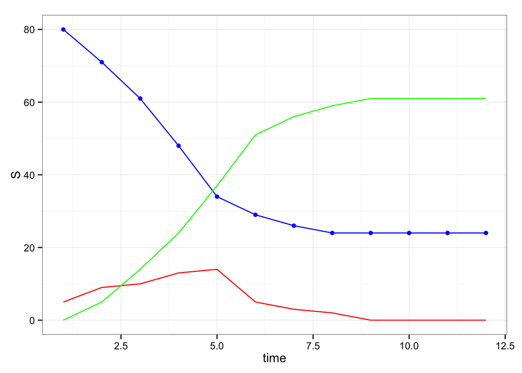

Set up the required arguments to run the JAGS model

```r
data <- list(obs = sim$Iobs,
             pop = pop,
             numobs = nrow(sim),
             r0 = r0)

inits <- list(list(
  I = sim$I*1,
  effpropS = effpropS - 0.1,
  effpropI = effpropI - 0.15,
  beta = beta + .05,
  reporting = reporting),
list(
  I = sim$I*1 + 1,
  effpropS = effpropS - 0.1,
  effpropI = effpropI + 0.2,
  beta = beta + .1,
  reporting = reporting),
list(
  I = sim$I*1 + 2,
  effpropS = effpropS,
  effpropI = effpropI,
  beta = beta - .008,
  reporting = reporting)
)

params = c("beta",
           "effpropS",
           "effpropI",
           "reporting")

#rjags::set.factory("bugs::Conjugate", FALSE, type="sampler")
```

Create the model and examine the MCMC algorithms that JAGS will use to sample

```r
cbjagsmodel <- jags.model(data = data,
               inits = inits,
               file = "CB.bug",
               n.chains = length(inits))
```

```
##    Graph Size: 84
##
```

```r
list.samplers(cbjagsmodel)
```

```
## $ShiftedCount
## [1] "I[12]"
##
## $DiscreteSlicer
## [1] "I[11]"
##
## $DiscreteSlicer
## [1] "I[10]"
##
## $DiscreteSlicer
## [1] "I[9]"
##
## $DiscreteSlicer
## [1] "I[8]"
##
## $DiscreteSlicer
## [1] "I[7]"
##
## $DiscreteSlicer
## [1] "I[6]"
##
## $DiscreteSlicer
## [1] "I[5]"
##
## $DiscreteSlicer
## [1] "I[4]"
##
## $DiscreteSlicer
## [1] "I[3]"
##
## $DiscreteSlicer
## [1] "I[2]"
##
## $DiscreteSlicer
## [1] "I[1]"
##
## $DiscreteSlicer
## [1] "S[1]"
##
## $RealSlicer
## [1] "beta"
##
## $ConjugateBeta
## [1] "effpropI"
##
## $ConjugateBeta
## [1] "effpropS"
##
## $ConjugateBeta
## [1] "reporting"
```

Run some chains (could use coda::coda.samples from cbjagsmodel but here we will just run jags())

```r
coda.samples(cbjagsmodel, c("beta", "effpropS", "effpropI", "reporting"), 1000)
```

Run through jags

```r
jagstime <- system.time(cbjags <- jags(data = data,
               inits = inits,
               param = params,
               model.file = "CB.bug",
               n.iter = 11000,
               n.burnin = 1000,
               n.thin = 20,
               n.chains = length(inits)))
```

```
## module glm loaded
```

```
##    Graph Size: 84
##
```

```r
cbjags
```

```
## Inference for Bugs model at "CB.bug", fit using jags,
##  3 chains, each with 11000 iterations (first 1000 discarded), n.thin = 20
##  n.sims = 1500 iterations saved
##           mu.vect sd.vect   2.5%    25%    50%    75%  97.5%  Rhat n.eff
## beta        0.026   0.008  0.015  0.021  0.025  0.030  0.045 1.002  1500
## effpropI    0.398   0.262  0.047  0.179  0.333  0.589  0.951 1.001  1500
## effpropS    0.801   0.128  0.484  0.726  0.833  0.901  0.962 1.001  1500
## reporting   0.475   0.111  0.317  0.396  0.456  0.535  0.755 1.003   970
## deviance   29.884   3.996 21.839 27.413 29.819 32.349 37.958 1.006   760
##
## For each parameter, n.eff is a crude measure of effective sample size,
## and Rhat is the potential scale reduction factor (at convergence, Rhat=1).
##
## DIC info (using the rule, pD = var(deviance)/2)
## pD = 8.0 and DIC = 37.9
## DIC is an estimate of expected predictive error (lower deviance is better).
```

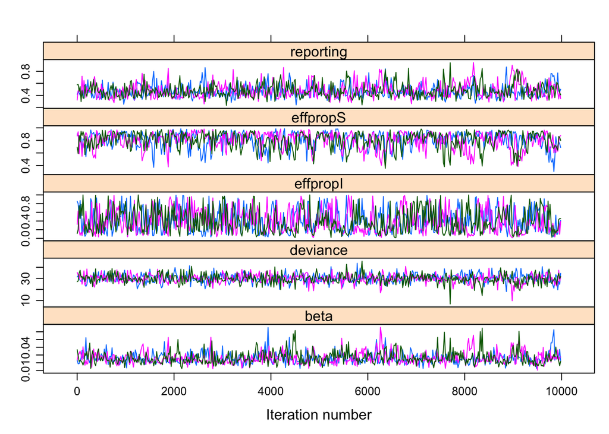

```r
xyplot(as.mcmc(cbjags))
```

##### 1.2 Build the NIMLE model

```r
source('nimCBMK.R')
```

Set up the model. Here we need: Constants, Data, Initial Values, NIMBLE model object

```r
nimCBdata <- list(obs = sim$Iobs)

nimCBcon <- list(numobs = numobs, pop = pop, r0 = r0)

nimCBinits <- list(I = sim$I,
                   effpropS = effpropS,
                   effpropI = effpropI,
                   beta = beta,
                   reporting = reporting,
                   s0 = s0)

nimtimevec[1] <- system.time(CBout <- nimbleModel(code = nimcode,
                         name = 'CBout',
                         constants = nimCBcon,
                         data = nimCBdata,
                         inits = nimCBinits))[3]
```

```
## defining model...
## building model...
## setting data and initial values...
## checking model...   (use nimbleModel(..., check = FALSE) to skip model check)
## model building finished
```

##### 1.2.1 Model exploration/conversion

```r
CBout$getNodeNames()
```

```
##  [1] "reporting"            "effpropS"             "effpropI"
##  [4] "beta"                 "R[1]"                 "s0"
##  [7] "lifted_d100_minus_s0" "S[1]"                 "I[1]"
## [10] "pSI[1]"               "obs[1]"               "R[2]"
## [13] "I[2]"                 "S[2]"                 "R[3]"
## [16] "pSI[2]"               "obs[2]"               "I[3]"
## [19] "S[3]"                 "R[4]"                 "pSI[3]"
## [22] "obs[3]"               "I[4]"                 "S[4]"
## [25] "R[5]"                 "pSI[4]"               "obs[4]"
## [28] "I[5]"                 "S[5]"                 "R[6]"
## [31] "pSI[5]"               "obs[5]"               "I[6]"
## [34] "S[6]"                 "R[7]"                 "pSI[6]"
## [37] "obs[6]"               "I[7]"                 "S[7]"
## [40] "R[8]"                 "pSI[7]"               "obs[7]"
## [43] "I[8]"                 "S[8]"                 "R[9]"
## [46] "pSI[8]"               "obs[8]"               "I[9]"
## [49] "S[9]"                 "R[10]"                "pSI[9]"
## [52] "obs[9]"               "I[10]"                "S[10]"
## [55] "R[11]"                "pSI[10]"              "obs[10]"
## [58] "I[11]"                "S[11]"                "R[12]"
## [61] "pSI[11]"              "obs[11]"              "I[12]"
## [64] "S[12]"                "pSI[12]"              "obs[12]"
```

You can examine a single specific node using:

```r
CBout[['I[2]']]
```

```
## [1] 9
```

```r
CBout$obs
```

```
##  [1]  2  7  3  7 10  2  1  1  0  0  0  0
```

nimbleModel does its best to initialize a model, but let’s say you want to re-initialize I.

```r
simulate(CBout, 'I') # using the current beta -- if we update beta to a new value this will change
CBout$I
```

```
##  [1]  2 12 14  6 11  9  5  1  0  0  0  0
```

And take a look at the log-prob

```r
calculate(CBout, "I")
```

```
## [1] -19.49213
```

```r
CBout$logProb_I
```

```
##  [1] -1.988436 -3.250441 -2.368823 -3.471141 -1.996278 -1.904276 -2.452419
##  [8] -1.090584 -0.969730  0.000000  0.000000  0.000000
```

```r
I2lp <- CBout$nodes[['I[2]']]$calculate()
I2lp
```

```
## [1] -3.250441
```

or Calculate new log probabilities after updating I

```r
CBout$obs
```

```
##  [1]  2  7  3  7 10  2  1  1  0  0  0  0
```

```r
getLogProb(CBout, 'obs')
```

```
## [1] -13.15753
```

```r
calculate(CBout, CBout$getDependencies(c("obs")))
```

```
## [1] -Inf
```

```r
CBout$logProb_obs
```

```
##  [1] -1.3862944 -1.6432048 -3.8069067       -Inf -5.2267237 -2.6548057
##  [7] -1.8562980 -0.6931472  0.0000000  0.0000000  0.0000000  0.0000000
```

We can also look at the dependencies to make sense of what is going on

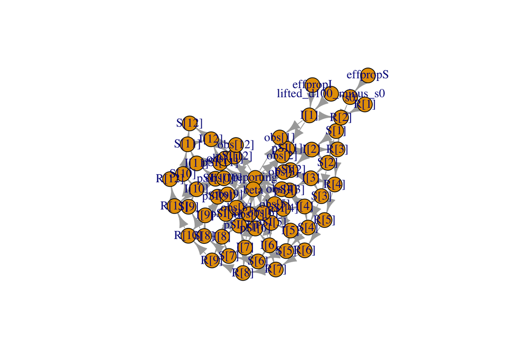

```r
par(mfrow = c(1,1))
plot(CBout$graph)
```

```r
CBout$getDependencies(c("beta"))
```

```
##  [1] "beta"    "pSI[1]"  "I[2]"    "pSI[2]"  "I[3]"    "pSI[3]"  "I[4]"
##  [8] "pSI[4]"  "I[5]"    "pSI[5]"  "I[6]"    "pSI[6]"  "I[7]"    "pSI[7]"
## [15] "I[8]"    "pSI[8]"  "I[9]"    "pSI[9]"  "I[10]"   "pSI[10]" "I[11]"
## [22] "pSI[11]" "I[12]"   "pSI[12]"
```

```r
CBout$getDependencies(c("beta"), determOnly = TRUE)
```

```
##  [1] "pSI[1]"  "pSI[2]"  "pSI[3]"  "pSI[4]"  "pSI[5]"  "pSI[6]"  "pSI[7]"
##  [8] "pSI[8]"  "pSI[9]"  "pSI[10]" "pSI[11]" "pSI[12]"
```

We will return to nimbleFunctions later – but here is an initial example nimbleFunction that will simulate multiple values for a designated set of nodes and calculate every part of the model that depends on them

```r
simNodesMany <- nimbleFunction( setup = function(model, nodes) {
        mv <- modelValues(model)
        deps <- model$getDependencies(nodes)
        allNodes <- model$getNodeNames()
},
run = function(n = integer()) {
  resize(mv, n)
  for(i in 1:n) {
            simulate(model, nodes)
            calculate(model, deps)
            copy(from = model, nodes = allNodes,
to = mv, rowTo = i, logProb = TRUE) }
})
```

```r
outI <- simNodesMany(CBout, "I")

outI$run(1)

outI$mv[["logProb_obs"]]
```

```
## [[1]]
##  [1] -1.1631508 -1.8255263 -5.7722349 -1.5631621 -1.7902195 -3.1248093
##  [7] -0.6931472 -0.6931472 -3.4657359  0.0000000  0.0000000  0.0000000
```

##### 1.2.2 Compile the C++ model, build the MCMC and Run

```r
nimtimevec[2] <- system.time(CBoutC <- compileNimble(CBout))[3]
```

Configure the MCMC with the default options (we will return to customizing this setup later)

```r
nimtimevec[3] <- system.time(CBoutSpec <- configureMCMC(CBout, print = TRUE))[3]
```

```
## [1] RW sampler: reporting,  adaptive: TRUE,  adaptInterval: 200,  scale: 1
## [2] RW sampler: effpropS,  adaptive: TRUE,  adaptInterval: 200,  scale: 1
## [3] RW sampler: effpropI,  adaptive: TRUE,  adaptInterval: 200,  scale: 1
## [4] RW sampler: beta,  adaptive: TRUE,  adaptInterval: 200,  scale: 1
## [5] slice sampler: s0,  adaptive: TRUE,  adaptInterval: 200,  sliceWidth: 1,  sliceMaxSteps: 100
## [6] slice sampler: I[1],  adaptive: TRUE,  adaptInterval: 200,  sliceWidth: 1,  sliceMaxSteps: 100
## [7] slice sampler: I[2],  adaptive: TRUE,  adaptInterval: 200,  sliceWidth: 1,  sliceMaxSteps: 100
## [8] slice sampler: I[3],  adaptive: TRUE,  adaptInterval: 200,  sliceWidth: 1,  sliceMaxSteps: 100
## [9] slice sampler: I[4],  adaptive: TRUE,  adaptInterval: 200,  sliceWidth: 1,  sliceMaxSteps: 100
## [10] slice sampler: I[5],  adaptive: TRUE,  adaptInterval: 200,  sliceWidth: 1,  sliceMaxSteps: 100
## [11] slice sampler: I[6],  adaptive: TRUE,  adaptInterval: 200,  sliceWidth: 1,  sliceMaxSteps: 100
## [12] slice sampler: I[7],  adaptive: TRUE,  adaptInterval: 200,  sliceWidth: 1,  sliceMaxSteps: 100
## [13] slice sampler: I[8],  adaptive: TRUE,  adaptInterval: 200,  sliceWidth: 1,  sliceMaxSteps: 100
## [14] slice sampler: I[9],  adaptive: TRUE,  adaptInterval: 200,  sliceWidth: 1,  sliceMaxSteps: 100
## [15] slice sampler: I[10],  adaptive: TRUE,  adaptInterval: 200,  sliceWidth: 1,  sliceMaxSteps: 100
## [16] slice sampler: I[11],  adaptive: TRUE,  adaptInterval: 200,  sliceWidth: 1,  sliceMaxSteps: 100
## [17] slice sampler: I[12],  adaptive: TRUE,  adaptInterval: 200,  sliceWidth: 1,  sliceMaxSteps: 100
```

Add chain monitors for the parameters of interest and add thinning

```r
CBoutSpec$addMonitors(c("beta", "effpropS", "effpropI", "reporting"))
```

```
## thin = 1: reporting, effpropS, effpropI, beta
```

```r
CBoutSpec$setThin(20)
```

```
## thin = 20: reporting, effpropS, effpropI, beta
```

Build the MCMC

```r
nimtimevec[4] <- system.time(CBoutMCMC <- buildMCMC(CBoutSpec))[3]

nimtimevec[5] <- system.time(CBoutMCMC <- compileNimble(CBoutMCMC, project = CBout, resetFunctions = TRUE))[3]
```

```r
niter <- 11000

set.seed(0)
nimtimevec[6] <- system.time(CBoutMCMC$run(niter))[3]
  # mcmc$run(niter, reset = FALSE) can be used to add more iterations
```

Quick peek at time required. Below we will take a look at efficiency using a convenient coda function

Gross time required

```r
jagstime[3]
```

```
## elapsed
##   7.338
```

```r
sum(nimtimevec[1:6], na.rm = TRUE)
```

```
## [1] 14.724
```

```r
nimtimevec[6]
```

```
## [1] 0.776
```

Efficiency (Net time in a sense)

```r
samples <- as.matrix(CBoutMCMC$mvSamples)

head(samples)
```

```
##            beta   effpropI  effpropS reporting
## [1,] 0.03464681 0.08272335 0.8000000 0.5000000
## [2,] 0.03464681 0.15089324 0.7829766 0.4375409
## [3,] 0.03464681 0.13588344 0.7829766 0.4294853
## [4,] 0.03464681 0.05387897 0.6427986 0.5627820
## [5,] 0.03464681 0.27545555 0.6427986 0.5412855
## [6,] 0.03464681 0.22183506 0.6427986 0.4851324
```

```r
jags_eff <- effectiveSize(as.mcmc.list(as.mcmc(cbjags))) / nimtimevec[1]
nim_eff <- effectiveSize(as.mcmc.list(as.mcmc(samples))) / nimtimevec[6]

jags_eff
```

```
##      beta  deviance  effpropI  effpropS reporting
##  692.7038 1235.3970  554.8536  438.8780  716.9121
```

```r
nim_eff
```

```
##      beta  effpropI  effpropS reporting
## 123.85091 106.36785  81.82033 202.52744
```

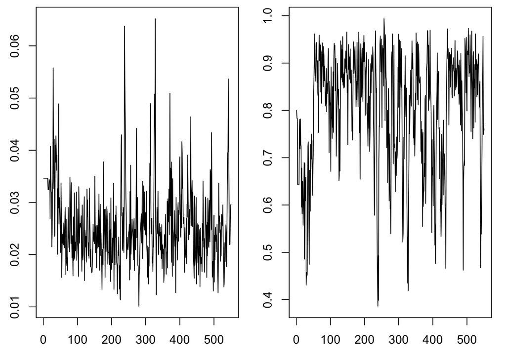

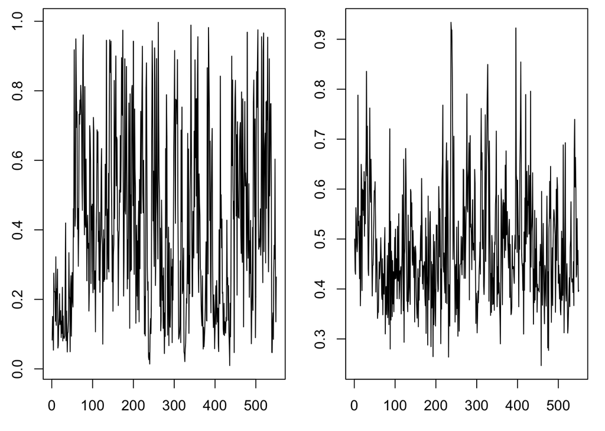

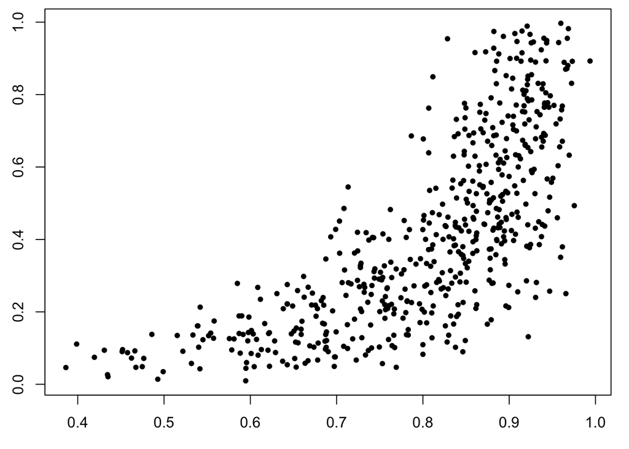

Save these points for later

```r
  def_effS <- samples[ , 'effpropS']
  def_effI <- samples[ , 'effpropI']
```

Look at the correlation in the chains

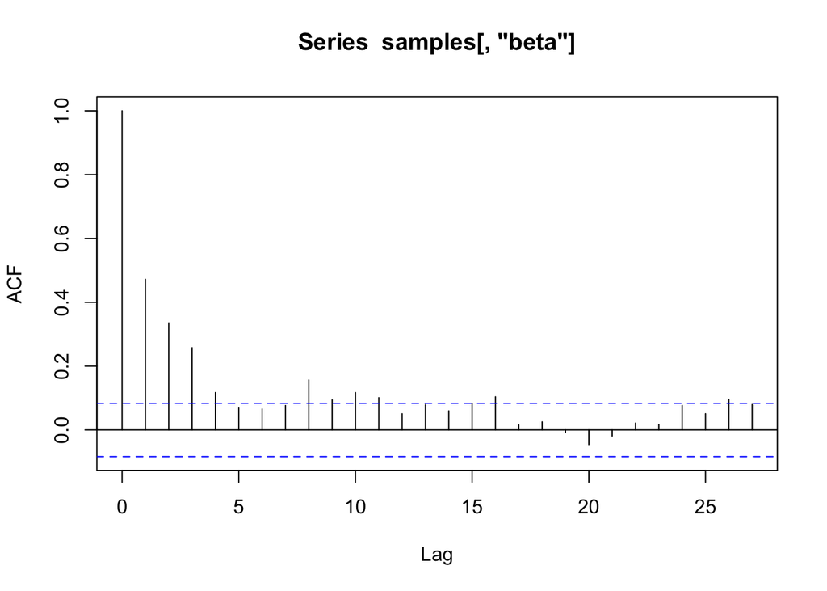

```r
  acf(samples[, "beta"])
```

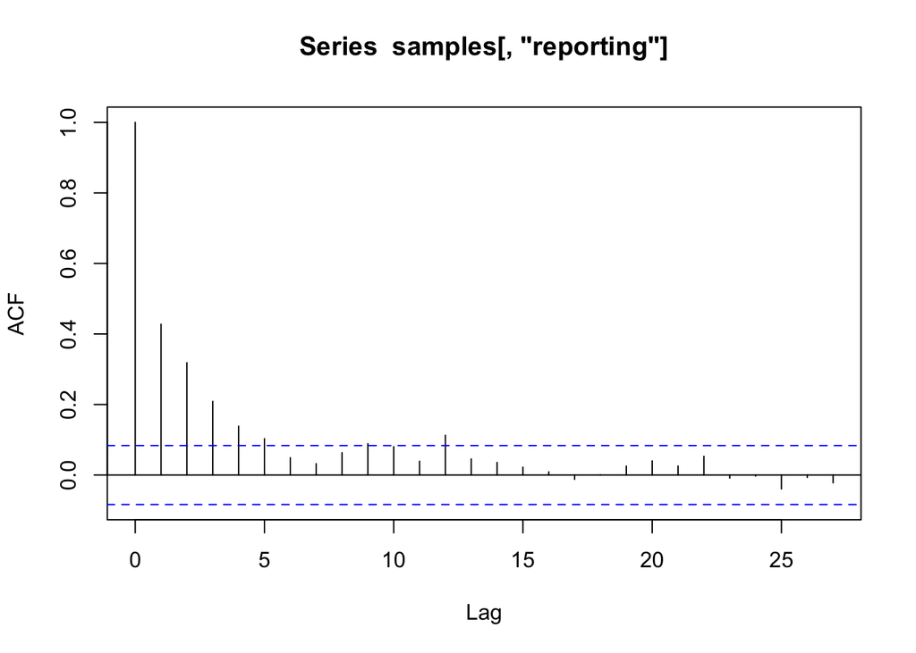

```r
  acf(samples[, "reporting"])
```

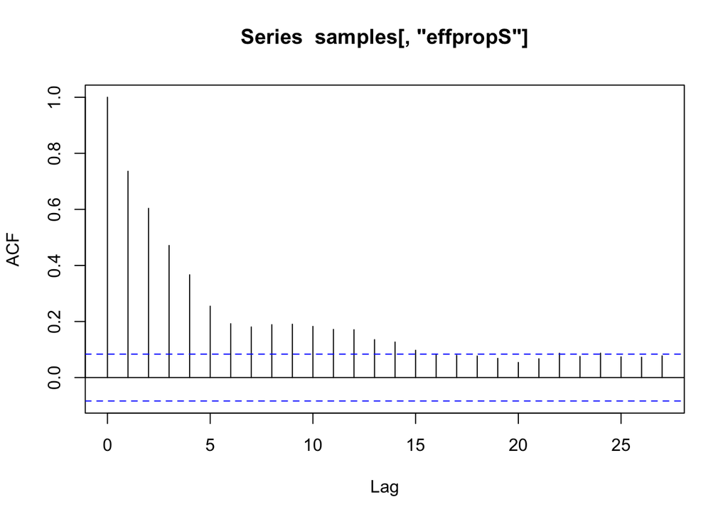

```r
  acf(samples[, "effpropS"])
```

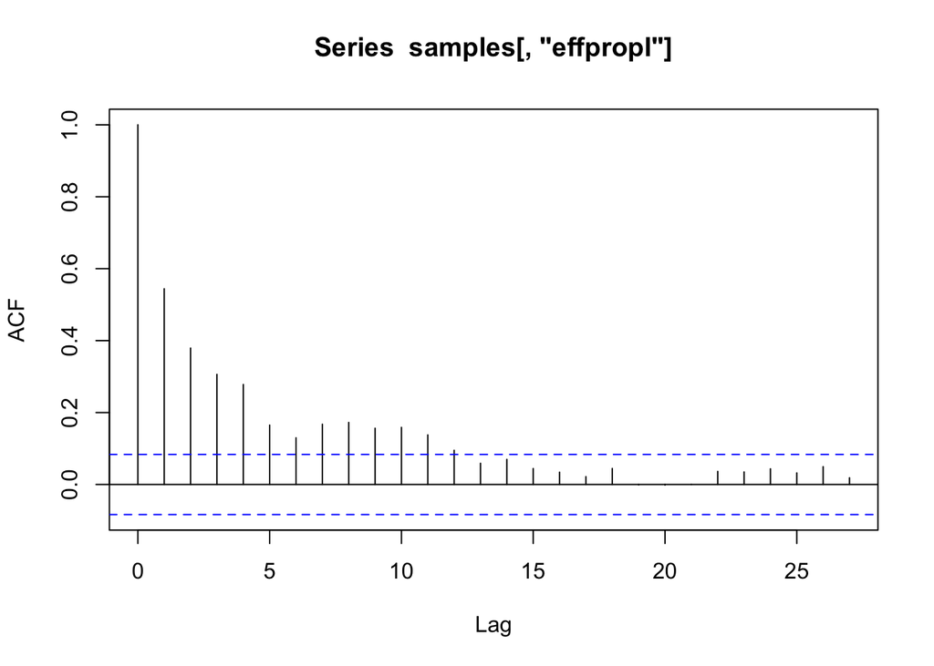

```r
  acf(samples[, "effpropI"])
```

##### 1.2.3 Small MCMC specification adjustment

A few undesirable results here… we can add a block sampler to decrease correlation

Take a look at the samplers being used

```r
CBoutSpec$getSamplers()
```

```
## [1]  RW sampler: reporting,  adaptive: TRUE,  adaptInterval: 200,  scale: 1
## [2]  RW sampler: effpropS,  adaptive: TRUE,  adaptInterval: 200,  scale: 1
## [3]  RW sampler: effpropI,  adaptive: TRUE,  adaptInterval: 200,  scale: 1
## [4]  RW sampler: beta,  adaptive: TRUE,  adaptInterval: 200,  scale: 1
## [5]  slice sampler: s0,  adaptive: TRUE,  adaptInterval: 200,  sliceWidth: 1,  sliceMaxSteps: 100
## [6]  slice sampler: I[1],  adaptive: TRUE,  adaptInterval: 200,  sliceWidth: 1,  sliceMaxSteps: 100
## [7]  slice sampler: I[2],  adaptive: TRUE,  adaptInterval: 200,  sliceWidth: 1,  sliceMaxSteps: 100
## [8]  slice sampler: I[3],  adaptive: TRUE,  adaptInterval: 200,  sliceWidth: 1,  sliceMaxSteps: 100
## [9]  slice sampler: I[4],  adaptive: TRUE,  adaptInterval: 200,  sliceWidth: 1,  sliceMaxSteps: 100
## [10] slice sampler: I[5],  adaptive: TRUE,  adaptInterval: 200,  sliceWidth: 1,  sliceMaxSteps: 100
## [11] slice sampler: I[6],  adaptive: TRUE,  adaptInterval: 200,  sliceWidth: 1,  sliceMaxSteps: 100
## [12] slice sampler: I[7],  adaptive: TRUE,  adaptInterval: 200,  sliceWidth: 1,  sliceMaxSteps: 100
## [13] slice sampler: I[8],  adaptive: TRUE,  adaptInterval: 200,  sliceWidth: 1,  sliceMaxSteps: 100
## [14] slice sampler: I[9],  adaptive: TRUE,  adaptInterval: 200,  sliceWidth: 1,  sliceMaxSteps: 100
## [15] slice sampler: I[10],  adaptive: TRUE,  adaptInterval: 200,  sliceWidth: 1,  sliceMaxSteps: 100
## [16] slice sampler: I[11],  adaptive: TRUE,  adaptInterval: 200,  sliceWidth: 1,  sliceMaxSteps: 100
## [17] slice sampler: I[12],  adaptive: TRUE,  adaptInterval: 200,  sliceWidth: 1,  sliceMaxSteps: 100
```

```r
CBoutSpec$addSampler(target = c('effpropS', 'effpropI'), type = 'RW_block',
                      control = list(adaptInterval = 10000))
```

```
## [18] RW_block sampler: effpropS, effpropI,  adaptive: TRUE,  adaptScaleOnly: FALSE,  adaptInterval: 10000,  scale: 1,  propCov: identity
```

```r
CBoutSpec$setThin(30)
```

```
## thin = 30: reporting, effpropS, effpropI, beta
```

```r
CBoutMCMC <- buildMCMC(CBoutSpec)
```

```r
CBoutMCMC <- compileNimble(CBoutMCMC, project  = CBout, resetFunctions = TRUE)
```

```r
CBoutMCMC$run(30000)
```

```r
samplesNew <- as.matrix(CBoutMCMC$mvSamples)
```

Check for an imporvement

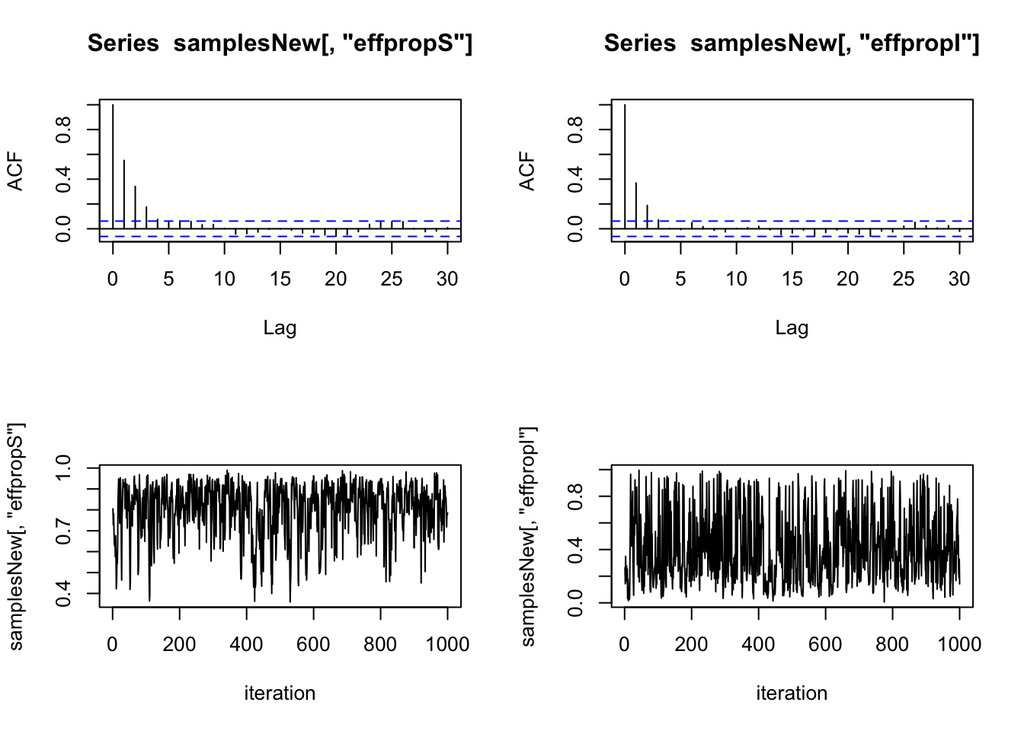

```r
  par(mfrow = c(2,2))
  acf(samplesNew[, "effpropS"])
  acf(samplesNew[, "effpropI"])
  plot(samplesNew[ , 'effpropS'], type = 'l', xlab = 'iteration')
  plot(samplesNew[ , 'effpropI'], type = 'l', xlab = 'iteration')
```

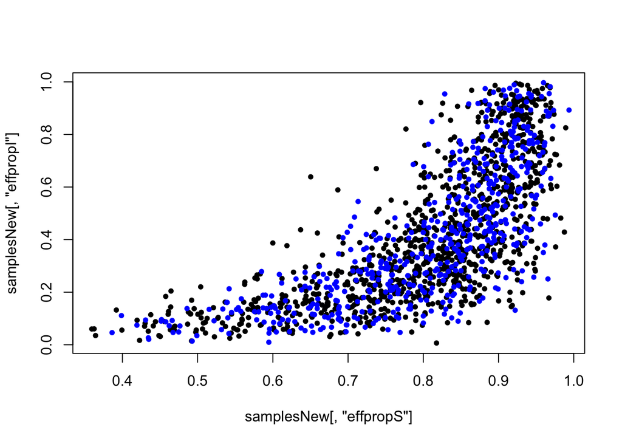

```r
  par(mfrow = c(1,1))
  plot(samplesNew[ , 'effpropS'], samplesNew[ , 'effpropI'], pch = 20)
  points(def_effS, def_effI, pch = 20, col = "blue")
```

Well that didn’t do anything…

NIMBLE allows for specification of samplers by parameter or node by node (NIMBLE included or user created)

e.g.

```r
CBoutSpec$removeSamplers(c("beta", "effpropS", "effpropI", "reporting"), print = TRUE)
CBoutSpec$addSampler("beta", type = "slice", print = TRUE)
CBoutSpec$addSampler("effpropS", type = "slice", print = TRUE)
CBoutSpec$addSampler("effpropI", type = "slice", print = TRUE)
CBoutSpec$addSampler("reporting", type = "slice", print = TRUE)
```

##### 1.3 Compare the JAGS and NIMBLE results

We can also compare the NIMBLE model simultaneously with the JAGS model using MCMCsuite()

Be warned: running this code with “makePlot = TRUE” will produce about 6-8 graphs which will all pop up in separate windows!

```r
source("simulateCB.R")
options(mc.cores = parallel::detectCores())
source('nimCB.R')

nimCBdata <- list(obs=sim$Iobs)
nimCBcon <- list(numobs=numobs,N=N,i0=i0)

nimCBinits <- list(I=sim$I,
                   effprop=effprop,
                   beta=beta,
                   reporting=reporting,
                   N0=N0
)
NimbleCB <- MCMCsuite(code=nimcode,
                   data=nimCBdata,
                   inits=nimCBinits,
                   constants=nimCBcon,
                   MCMCs=c("jags","nimble"),
                   monitors=c("beta","reporting","effprop"),
                   calculateEfficiency=TRUE,
                   niter=iterations,
                   makePlot=FALSE,
                   savePlot=FALSE,
                   setSeed = 5)
```

```
## defining model...
## building model...
## setting data and initial values...
## checking model...   (use nimbleModel(..., check = FALSE) to skip model check)
## model building finished
```

```
##    Graph Size: 61
##
```

```r
print(NimbleCB$timing)
```

```
##           jags         nimble nimble_compile
##          0.967          0.269         11.730
```

```r
print(NimbleCB$summary)
```

```
## , , beta
##
##              mean     median           sd   CI95_low   CI95_upp    n
## jags   0.01981122 0.01979022 0.0010274105 0.01784991 0.02180345 6000
## nimble 0.01971976 0.01971859 0.0009889842 0.01786407 0.02168437 6000
##             ess efficiency
## jags   2714.465   2807.099
## nimble 1434.733   5333.581
##
## , , reporting
##
##             mean    median         sd  CI95_low  CI95_upp    n      ess
## jags   0.7941674 0.7943665 0.01425585 0.7661751 0.8216472 6000 5697.514
## nimble 0.7940784 0.7949180 0.01459948 0.7649926 0.8218693 6000 1352.519
##        efficiency
## jags     5891.949
## nimble   5027.951
##
## , , effprop
##
##             mean    median         sd  CI95_low  CI95_upp    n      ess
## jags   0.7994306 0.7994792 0.01247361 0.7734830 0.8232036 6000 6000.000
## nimble 0.8001337 0.8000622 0.01215137 0.7758181 0.8235634 6000 1433.498
##        efficiency
## jags     6204.757
## nimble   5328.989
```

It is kind of scary considering Nimble is suppose to be this awesome super fast magic box. Before we learn Nimble, let’s take a few minutes learning JAGS and samplers.

```r
rjags::set.factory("bugs::Conjugate", FALSE, type="sampler")
```

```r
Jagsmod <- jags.model(file="CB2.bug",data=data,inits=inits)
```

```
##    Graph Size: 61
##
```

```r
list.samplers(Jagsmod)
```

```
## $DiscreteSlicer
## [1] "I[10]"
##
## $DiscreteSlicer
## [1] "I[9]"
##
## $DiscreteSlicer
## [1] "I[8]"
##
## $DiscreteSlicer
## [1] "I[7]"
##
## $DiscreteSlicer
## [1] "I[6]"
##
## $DiscreteSlicer
## [1] "I[5]"
##
## $DiscreteSlicer
## [1] "I[4]"
##
## $DiscreteSlicer
## [1] "I[3]"
##
## $DiscreteSlicer
## [1] "I[2]"
##
## $FiniteMethod
## [1] "I[1]"
##
## $DiscreteSlicer
## [1] "N0"
##
## $RealSlicer
## [1] "beta"
##
## $RealSlicer
## [1] "effprop"
##
## $RealSlicer
## [1] "reporting"
```

```r
slicetime <- system.time(JagsCB <- jags(data=data,
               inits=inits,
               param = params,
               model.file = "CB2.bug",
               n.iter = iterations,
               n.chains = length(inits),
               n.thin = 1,
               n.burnin = 2000
               ))
```

```
##    Graph Size: 61
##
```

```r
print(JagsCB)
```

```
## Inference for Bugs model at "CB2.bug", fit using jags,
##  1 chains, each with 8000 iterations (first 2000 discarded)
##  n.sims = 6000 iterations saved
##           mu.vect sd.vect   2.5%    25%    50%    75%  97.5%
## beta        0.020   0.001  0.018  0.019  0.020  0.020  0.022
## effprop     0.800   0.013  0.775  0.792  0.801  0.809  0.824
## reporting   0.793   0.014  0.765  0.784  0.794  0.803  0.820
## deviance   19.078   1.434 18.104 18.200 18.538 19.414 22.866
##
## DIC info (using the rule, pD = var(deviance)/2)
## pD = 1.0 and DIC = 20.1
## DIC is an estimate of expected predictive error (lower deviance is better).
```

```r
slice_eff <- effectiveSize(as.mcmc(JagsCB))/slicetime[3]


rjags::set.factory("bugs::Conjugate", TRUE, type="sampler")
```

```r
Jagsmod2 <- jags.model(file="CB2.bug",data=data,inits=inits)
```

```
##    Graph Size: 61
##
```

```r
list.samplers(Jagsmod2)
```

```
## $ShiftedCount
## [1] "I[10]"
##
## $DiscreteSlicer
## [1] "I[9]"
##
## $DiscreteSlicer
## [1] "I[8]"
##
## $DiscreteSlicer
## [1] "I[7]"
##
## $DiscreteSlicer
## [1] "I[6]"
##
## $DiscreteSlicer
## [1] "I[5]"
##
## $DiscreteSlicer
## [1] "I[4]"
##
## $DiscreteSlicer
## [1] "I[3]"
##
## $DiscreteSlicer
## [1] "I[2]"
##
## $FiniteMethod
## [1] "I[1]"
##
## $DiscreteSlicer
## [1] "N0"
##
## $RealSlicer
## [1] "beta"
##
## $ConjugateBeta
## [1] "effprop"
##
## $ConjugateBeta
## [1] "reporting"
```

```r
conjutime <- system.time(JagsCB2 <- jags(data=data,
               inits=inits,
               param = params,
               model.file = "CB2.bug",
               n.iter = iterations,
               n.chains = length(inits),
               n.thin = 1,
               n.burnin = 2000
               ))
```

```
##    Graph Size: 61
##
```

```r
print(JagsCB)
```

```
## Inference for Bugs model at "CB2.bug", fit using jags,
##  1 chains, each with 8000 iterations (first 2000 discarded)
##  n.sims = 6000 iterations saved
##           mu.vect sd.vect   2.5%    25%    50%    75%  97.5%
## beta        0.020   0.001  0.018  0.019  0.020  0.020  0.022
## effprop     0.800   0.013  0.775  0.792  0.801  0.809  0.824
## reporting   0.793   0.014  0.765  0.784  0.794  0.803  0.820
## deviance   19.078   1.434 18.104 18.200 18.538 19.414 22.866
##
## DIC info (using the rule, pD = var(deviance)/2)
## pD = 1.0 and DIC = 20.1
## DIC is an estimate of expected predictive error (lower deviance is better).
```

```r
print(JagsCB2)
```

```
## Inference for Bugs model at "CB2.bug", fit using jags,
##  1 chains, each with 8000 iterations (first 2000 discarded)
##  n.sims = 6000 iterations saved
##           mu.vect sd.vect   2.5%    25%    50%    75%  97.5%
## beta        0.020   0.001  0.018  0.019  0.020  0.020  0.022
## effprop     0.800   0.013  0.775  0.792  0.800  0.808  0.824
## reporting   0.794   0.014  0.765  0.785  0.795  0.804  0.822
## deviance   19.053   1.452 18.044 18.143 18.479 19.370 23.159
##
## DIC info (using the rule, pD = var(deviance)/2)
## pD = 1.1 and DIC = 20.1
## DIC is an estimate of expected predictive error (lower deviance is better).
```

```r
conju_eff <- effectiveSize(as.mcmc(JagsCB2))/conjutime[3]

slicetime
```

```
##    user  system elapsed
##   1.122   0.006   1.133
```

```r
conjutime
```

```
##    user  system elapsed
##   0.986   0.015   1.012
```

```r
slice_eff
```

```
##      beta  deviance   effprop reporting
##  3341.832  2115.318  3519.787  3336.386
```

```r
conju_eff
```

```
##      beta  deviance   effprop reporting
##  3425.307  5928.854  5928.854  5928.854
```

Wow, that is pretty cool. Let’s try to do it in Nimble.

```r
NimbleCB <- MCMCsuite(code=nimcode,
                   data=nimCBdata,
                   inits=nimCBinits,
                   constants=nimCBcon,
                   MCMCs=c("jags","nimble","nimble_slice"),
                   monitors=c("beta","reporting","effprop"),
                   calculateEfficiency=TRUE,
                   niter=iterations,
                   makePlot=FALSE,
                   savePlot=FALSE,
                   setSeed = 5)
```

```
## defining model...
## building model...
## setting data and initial values...
## checking model...   (use nimbleModel(..., check = FALSE) to skip model check)
## model building finished
```

```
##    Graph Size: 61
##
```

```r
print(NimbleCB$timing)
```

```
##           jags         nimble   nimble_slice nimble_compile
##          0.921          0.260          0.336         12.368
```

```r
print(NimbleCB$summary)
```

```
## , , beta
##
##                    mean     median           sd   CI95_low   CI95_upp    n
## jags         0.01977664 0.01976306 0.0010357794 0.01782251 0.02192138 6000
## nimble       0.01971976 0.01971859 0.0009889842 0.01786407 0.02168437 6000
## nimble_slice 0.01784789 0.01782115 0.0009514310 0.01604674 0.01978070 6000
##                    ess efficiency
## jags         3966.1159   4306.315
## nimble       1434.7334   5518.205
## nimble_slice  257.7466    767.103
##
## , , reporting
##
##                   mean    median         sd  CI95_low  CI95_upp    n
## jags         0.7940435 0.7943824 0.01427422 0.7650938 0.8208587 6000
## nimble       0.7940784 0.7949180 0.01459948 0.7649926 0.8218693 6000
## nimble_slice 0.7917124 0.7916635 0.01393216 0.7641873 0.8185188 6000
##                   ess efficiency
## jags         6000.000   6514.658
## nimble       1352.519   5201.995
## nimble_slice 5920.978  17621.960
##
## , , effprop
##
##                   mean    median         sd  CI95_low  CI95_upp    n
## jags         0.7994550 0.7994832 0.01266674 0.7740356 0.8241235 6000
## nimble       0.8001337 0.8000622 0.01215137 0.7758181 0.8235634 6000
## nimble_slice 0.8021424 0.8020508 0.01252640 0.7774144 0.8261720 6000
##                   ess efficiency
## jags         6000.000   6514.658
## nimble       1433.498   5513.454
## nimble_slice 3891.047  11580.498
```

```r
mod <- nimbleModel(code = nimcode, data=nimCBdata, inits=nimCBinits, constants=nimCBcon, name = "mod")
```

```
## defining model...
## building model...
## setting data and initial values...
## checking model...   (use nimbleModel(..., check = FALSE) to skip model check)
## model building finished
```

```r
temp <- compileNimble(mod) ## need to compile it once before recompiling changes
Cmod <- configureMCMC(mod,print=TRUE,useConjugacy = TRUE)
```

```
## [1] RW sampler: reporting,  adaptive: TRUE,  adaptInterval: 200,  scale: 1
## [2] RW sampler: effprop,  adaptive: TRUE,  adaptInterval: 200,  scale: 1
## [3] RW sampler: beta,  adaptive: TRUE,  adaptInterval: 200,  scale: 1
## [4] slice sampler: I[1],  adaptive: TRUE,  adaptInterval: 200,  sliceWidth: 1,  sliceMaxSteps: 100
## [5] slice sampler: N0,  adaptive: TRUE,  adaptInterval: 200,  sliceWidth: 1,  sliceMaxSteps: 100
## [6] slice sampler: I[2],  adaptive: TRUE,  adaptInterval: 200,  sliceWidth: 1,  sliceMaxSteps: 100
## [7] slice sampler: I[3],  adaptive: TRUE,  adaptInterval: 200,  sliceWidth: 1,  sliceMaxSteps: 100
## [8] slice sampler: I[4],  adaptive: TRUE,  adaptInterval: 200,  sliceWidth: 1,  sliceMaxSteps: 100
## [9] slice sampler: I[5],  adaptive: TRUE,  adaptInterval: 200,  sliceWidth: 1,  sliceMaxSteps: 100
## [10] slice sampler: I[6],  adaptive: TRUE,  adaptInterval: 200,  sliceWidth: 1,  sliceMaxSteps: 100
## [11] slice sampler: I[7],  adaptive: TRUE,  adaptInterval: 200,  sliceWidth: 1,  sliceMaxSteps: 100
## [12] slice sampler: I[8],  adaptive: TRUE,  adaptInterval: 200,  sliceWidth: 1,  sliceMaxSteps: 100
## [13] slice sampler: I[9],  adaptive: TRUE,  adaptInterval: 200,  sliceWidth: 1,  sliceMaxSteps: 100
## [14] slice sampler: I[10],  adaptive: TRUE,  adaptInterval: 200,  sliceWidth: 1,  sliceMaxSteps: 100
```

```r
Cmodslice <- configureMCMC(mod,print=TRUE,useConjugacy = TRUE, onlySlice = TRUE)
```

```
## [1] slice sampler: reporting,  adaptive: TRUE,  adaptInterval: 200,  sliceWidth: 1,  sliceMaxSteps: 100
## [2] slice sampler: effprop,  adaptive: TRUE,  adaptInterval: 200,  sliceWidth: 1,  sliceMaxSteps: 100
## [3] slice sampler: beta,  adaptive: TRUE,  adaptInterval: 200,  sliceWidth: 1,  sliceMaxSteps: 100
## [4] slice sampler: I[1],  adaptive: TRUE,  adaptInterval: 200,  sliceWidth: 1,  sliceMaxSteps: 100
## [5] slice sampler: N0,  adaptive: TRUE,  adaptInterval: 200,  sliceWidth: 1,  sliceMaxSteps: 100
## [6] slice sampler: I[2],  adaptive: TRUE,  adaptInterval: 200,  sliceWidth: 1,  sliceMaxSteps: 100
## [7] slice sampler: I[3],  adaptive: TRUE,  adaptInterval: 200,  sliceWidth: 1,  sliceMaxSteps: 100
## [8] slice sampler: I[4],  adaptive: TRUE,  adaptInterval: 200,  sliceWidth: 1,  sliceMaxSteps: 100
## [9] slice sampler: I[5],  adaptive: TRUE,  adaptInterval: 200,  sliceWidth: 1,  sliceMaxSteps: 100
## [10] slice sampler: I[6],  adaptive: TRUE,  adaptInterval: 200,  sliceWidth: 1,  sliceMaxSteps: 100
## [11] slice sampler: I[7],  adaptive: TRUE,  adaptInterval: 200,  sliceWidth: 1,  sliceMaxSteps: 100
## [12] slice sampler: I[8],  adaptive: TRUE,  adaptInterval: 200,  sliceWidth: 1,  sliceMaxSteps: 100
## [13] slice sampler: I[9],  adaptive: TRUE,  adaptInterval: 200,  sliceWidth: 1,  sliceMaxSteps: 100
## [14] slice sampler: I[10],  adaptive: TRUE,  adaptInterval: 200,  sliceWidth: 1,  sliceMaxSteps: 100
```

```r
Cmod$removeSamplers(c("reporting","beta","effprop"))
```

```
## [1]  slice sampler: I[1],  adaptive: TRUE,  adaptInterval: 200,  sliceWidth: 1,  sliceMaxSteps: 100
## [2]  slice sampler: N0,  adaptive: TRUE,  adaptInterval: 200,  sliceWidth: 1,  sliceMaxSteps: 100
## [3]  slice sampler: I[2],  adaptive: TRUE,  adaptInterval: 200,  sliceWidth: 1,  sliceMaxSteps: 100
## [4]  slice sampler: I[3],  adaptive: TRUE,  adaptInterval: 200,  sliceWidth: 1,  sliceMaxSteps: 100
## [5]  slice sampler: I[4],  adaptive: TRUE,  adaptInterval: 200,  sliceWidth: 1,  sliceMaxSteps: 100
## [6]  slice sampler: I[5],  adaptive: TRUE,  adaptInterval: 200,  sliceWidth: 1,  sliceMaxSteps: 100
## [7]  slice sampler: I[6],  adaptive: TRUE,  adaptInterval: 200,  sliceWidth: 1,  sliceMaxSteps: 100
## [8]  slice sampler: I[7],  adaptive: TRUE,  adaptInterval: 200,  sliceWidth: 1,  sliceMaxSteps: 100
## [9]  slice sampler: I[8],  adaptive: TRUE,  adaptInterval: 200,  sliceWidth: 1,  sliceMaxSteps: 100
## [10] slice sampler: I[9],  adaptive: TRUE,  adaptInterval: 200,  sliceWidth: 1,  sliceMaxSteps: 100
## [11] slice sampler: I[10],  adaptive: TRUE,  adaptInterval: 200,  sliceWidth: 1,  sliceMaxSteps: 100
```

```r
Cmod$addSampler(target = c("reporting","effprop"), type="RW_block")
```

```
## [12] RW_block sampler: reporting, effprop,  adaptive: TRUE,  adaptScaleOnly: FALSE,  adaptInterval: 200,  scale: 1,  propCov: identity
```

```r
Cmod$addSampler("beta",type="slice")
```

```
## [13] slice sampler: beta,  adaptive: TRUE,  adaptInterval: 200,  sliceWidth: 1,  sliceMaxSteps: 100
```

```r
Cmod$addMonitors(c("reporting","beta","effprop"))
```

```
## thin = 1: reporting, effprop, beta, I
```

```r
newMCMC <- buildMCMC(Cmod)
CnewMCMC <- compileNimble(newMCMC,project = mod, resetFunctions = TRUE)

Cnewtime <- system.time(CnewMCMC$run(iterations))
Cnewsample <- as.matrix(CnewMCMC$mvSamples)
effectiveSize(as.mcmc(Cnewsample[,c('beta','effprop','reporting')]))/Cnewtime[3]
```

```
##      beta   effprop reporting
## 12610.490  3422.227  2930.112
```

```r
NimbleCB <- MCMCsuite(code=nimcode,
                   data=nimCBdata,
                   inits=nimCBinits,
                   constants=nimCBcon,
                   MCMCs=c("jags","nimble","nimble_slice","newMCMC"),
                   monitors=c("beta","reporting","effprop"),
                   MCMCdefs = list(
                     newMCMC = quote({
                     Cmod <- configureMCMC(mod,print=FALSE,useConjugacy = TRUE)
                     Cmod$removeSamplers(c("reporting","beta","effprop"))
                     Cmod$addSampler(target = c("reporting","effprop"), type="RW_block")
                     Cmod$addSampler("beta",type="slice")
                     Cmod
                   })),
                   calculateEfficiency=TRUE,
                   niter=iterations,
                   makePlot=FALSE,
                   savePlot=FALSE,
                   setSeed = 5)
```

```
## defining model...
## building model...
## setting data and initial values...
## checking model...   (use nimbleModel(..., check = FALSE) to skip model check)
## model building finished
```

```
##    Graph Size: 61
##
##
## [1]  slice sampler: I[1],  adaptive: TRUE,  adaptInterval: 200,  sliceWidth: 1,  sliceMaxSteps: 100
## [2]  slice sampler: N0,  adaptive: TRUE,  adaptInterval: 200,  sliceWidth: 1,  sliceMaxSteps: 100
## [3]  slice sampler: I[2],  adaptive: TRUE,  adaptInterval: 200,  sliceWidth: 1,  sliceMaxSteps: 100
## [4]  slice sampler: I[3],  adaptive: TRUE,  adaptInterval: 200,  sliceWidth: 1,  sliceMaxSteps: 100
## [5]  slice sampler: I[4],  adaptive: TRUE,  adaptInterval: 200,  sliceWidth: 1,  sliceMaxSteps: 100
## [6]  slice sampler: I[5],  adaptive: TRUE,  adaptInterval: 200,  sliceWidth: 1,  sliceMaxSteps: 100
## [7]  slice sampler: I[6],  adaptive: TRUE,  adaptInterval: 200,  sliceWidth: 1,  sliceMaxSteps: 100
## [8]  slice sampler: I[7],  adaptive: TRUE,  adaptInterval: 200,  sliceWidth: 1,  sliceMaxSteps: 100
## [9]  slice sampler: I[8],  adaptive: TRUE,  adaptInterval: 200,  sliceWidth: 1,  sliceMaxSteps: 100
## [10] slice sampler: I[9],  adaptive: TRUE,  adaptInterval: 200,  sliceWidth: 1,  sliceMaxSteps: 100
## [11] slice sampler: I[10],  adaptive: TRUE,  adaptInterval: 200,  sliceWidth: 1,  sliceMaxSteps: 100
## [12] RW_block sampler: reporting, effprop,  adaptive: TRUE,  adaptScaleOnly: FALSE,  adaptInterval: 200,  scale: 1,  propCov: identity
## [13] slice sampler: beta,  adaptive: TRUE,  adaptInterval: 200,  sliceWidth: 1,  sliceMaxSteps: 100
```

```r
print(NimbleCB$timing)
```

```
##           jags         nimble   nimble_slice        newMCMC nimble_compile
##          0.936          0.249          0.325          0.318         15.891
```

```r
print(NimbleCB$summary)
```

```
## , , beta
##
##                    mean     median           sd   CI95_low   CI95_upp    n
## jags         0.01970797 0.01967531 0.0010327561 0.01777462 0.02183300 6000
## nimble       0.01971976 0.01971859 0.0009889842 0.01786407 0.02168437 6000
## nimble_slice 0.01784789 0.01782115 0.0009514310 0.01604674 0.01978070 6000
## newMCMC      0.01972793 0.01970314 0.0010369266 0.01782866 0.02183983 6000
##                    ess efficiency
## jags         3914.1002  4181.7310
## nimble       1434.7334  5761.9814
## nimble_slice  257.7466   793.0665
## newMCMC      6000.0000 18867.9245
##
## , , reporting
##
##                   mean    median         sd  CI95_low  CI95_upp    n
## jags         0.7934924 0.7935585 0.01439001 0.7647803 0.8210412 6000
## nimble       0.7940784 0.7949180 0.01459948 0.7649926 0.8218693 6000
## nimble_slice 0.7917124 0.7916635 0.01393216 0.7641873 0.8185188 6000
## newMCMC      0.7962769 0.7965268 0.01370457 0.7682597 0.8230912 6000
##                    ess efficiency
## jags         6000.0000   6410.256
## nimble       1352.5188   5431.803
## nimble_slice 5920.9784  18218.395
## newMCMC       749.1411   2355.790
##
## , , effprop
##
##                   mean    median         sd  CI95_low  CI95_upp    n
## jags         0.8004213 0.8006361 0.01232076 0.7758014 0.8236736 6000
## nimble       0.8001337 0.8000622 0.01215137 0.7758181 0.8235634 6000
## nimble_slice 0.8021424 0.8020508 0.01252640 0.7774144 0.8261720 6000
## newMCMC      0.7983015 0.7984716 0.01286115 0.7728959 0.8227836 6000
##                    ess efficiency
## jags         6000.0000   6410.256
## nimble       1433.4979   5757.020
## nimble_slice 3891.0473  11972.453
## newMCMC       800.0677   2515.936
```

```r
source("nimCB2.R")
mod2 <- nimbleModel(code = nimcode, data=nimCBdata, inits=nimCBinits, constants = nimCBcon,
                    name= "mod2")
```

```
## defining model...
## building model...
## setting data and initial values...
## checking model...   (use nimbleModel(..., check = FALSE) to skip model check)
## model building finished
```

```r
Cmod2 <- configureMCMC(mod2,print=TRUE)
```

```
## [1] conjugate_dbeta sampler: reporting,  dependents_dbin: obs[1], obs[2], obs[3], obs[4], obs[5], obs[6], obs[7], obs[8], obs[9], obs[10]
## [2] conjugate_dbeta sampler: effprop,  dependents_dbin: N0
## [3] RW sampler: beta,  adaptive: TRUE,  adaptInterval: 200,  scale: 1
## [4] slice sampler: I[1],  adaptive: TRUE,  adaptInterval: 200,  sliceWidth: 1,  sliceMaxSteps: 100
## [5] slice sampler: N0,  adaptive: TRUE,  adaptInterval: 200,  sliceWidth: 1,  sliceMaxSteps: 100
## [6] slice sampler: I[2],  adaptive: TRUE,  adaptInterval: 200,  sliceWidth: 1,  sliceMaxSteps: 100
## [7] slice sampler: I[3],  adaptive: TRUE,  adaptInterval: 200,  sliceWidth: 1,  sliceMaxSteps: 100
## [8] slice sampler: I[4],  adaptive: TRUE,  adaptInterval: 200,  sliceWidth: 1,  sliceMaxSteps: 100
## [9] slice sampler: I[5],  adaptive: TRUE,  adaptInterval: 200,  sliceWidth: 1,  sliceMaxSteps: 100
## [10] slice sampler: I[6],  adaptive: TRUE,  adaptInterval: 200,  sliceWidth: 1,  sliceMaxSteps: 100
## [11] slice sampler: I[7],  adaptive: TRUE,  adaptInterval: 200,  sliceWidth: 1,  sliceMaxSteps: 100
## [12] slice sampler: I[8],  adaptive: TRUE,  adaptInterval: 200,  sliceWidth: 1,  sliceMaxSteps: 100
## [13] slice sampler: I[9],  adaptive: TRUE,  adaptInterval: 200,  sliceWidth: 1,  sliceMaxSteps: 100
## [14] slice sampler: I[10],  adaptive: TRUE,  adaptInterval: 200,  sliceWidth: 1,  sliceMaxSteps: 100
```

```r
NimbleCB2 <- MCMCsuite(code=nimcode,
                   data=nimCBdata,
                   inits=nimCBinits,
                   constants=nimCBcon,
                   MCMCs=c("jags","nimble","nimble_slice"),
                   monitors=c("beta","reporting","effprop"),
                   calculateEfficiency=TRUE,
                   niter=iterations,
                   makePlot=FALSE,
                   savePlot=FALSE,
                   setSeed = 5)
```

```
## defining model...
## building model...
## setting data and initial values...
## checking model...   (use nimbleModel(..., check = FALSE) to skip model check)
## model building finished
```

```
##    Graph Size: 61
##
```

```r
print(NimbleCB$timing)
```

```
##           jags         nimble   nimble_slice        newMCMC nimble_compile
##          0.936          0.249          0.325          0.318         15.891
```

```r
print(NimbleCB2$timing)
```

```
##           jags         nimble   nimble_slice nimble_compile
##          0.872          0.304          0.422         14.168
```

```r
print(NimbleCB2$summary)
```

```
## , , beta
##
##                    mean     median          sd   CI95_low   CI95_upp    n
## jags         0.01924099 0.01919706 0.001078545 0.01728836 0.02145942 6000
## nimble       0.02006416 0.02005014 0.001033928 0.01812502 0.02218916 6000
## nimble_slice 0.01928614 0.01926719 0.001076191 0.01719862 0.02144204 6000
##                    ess efficiency
## jags          201.4686    231.042
## nimble       1429.2439   4701.460
## nimble_slice  232.2030    550.244
##
## , , reporting
##
##                   mean    median         sd  CI95_low  CI95_upp    n  ess
## jags         0.7925166 0.7929584 0.01433132 0.7634371 0.8197496 6000 6000
## nimble       0.7951029 0.7955497 0.01424706 0.7656243 0.8220509 6000 6000
## nimble_slice 0.7940640 0.7944421 0.01413819 0.7661565 0.8213829 6000 6000
##              efficiency
## jags           6880.734
## nimble        19736.842
## nimble_slice  14218.009
##
## , , effprop
##
##                   mean    median         sd  CI95_low  CI95_upp    n
## jags         0.8012189 0.8015467 0.01271493 0.7758620 0.8250791 6000
## nimble       0.7981156 0.7985524 0.01250704 0.7726403 0.8222761 6000
## nimble_slice 0.7999488 0.8003490 0.01260503 0.7751146 0.8239367 6000
##                   ess efficiency
## jags         4057.583   4653.191
## nimble       6000.000  19736.842
## nimble_slice 6000.000  14218.009
```

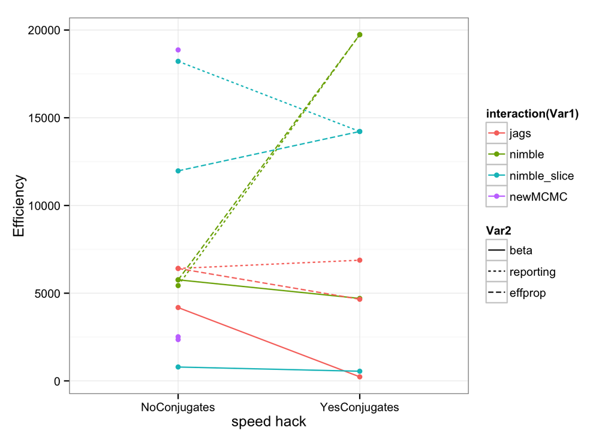

```r
mat1 <- as.array(NimbleCB$summary)
mat2 <- as.array(NimbleCB2$summary)
mat1 <- mat1[,"efficiency",]
mat2 <- mat2[,"efficiency",]
a1 <- melt(mat1)
a2 <- melt(mat2)
a1 <- cbind(a1,var3="NoConjugates")
a2 <- cbind(a2,var3="YesConjugates")
dat <- rbind(a1,a2)

ggplot(dat,aes(x=var3, y=value,group=interaction(Var1,Var2))) + geom_line(aes(color=interaction(Var1),linetype=Var2)) + geom_point(aes(color=Var1)) + theme_bw() + ylab('Efficiency') + xlab("speed hack")
```

MCMCsuite can also be used to compare models written in STAN which is described below